# Regresja i analiza wariancji - Laboratorium 10

Krzywa ROC i klasyfikacja wieloklasowa

Adrian Kowalski

Politechnika Krakowska

Wróćmy na chwilę do zbioru danych *breast* z poprzednich zajęć. Zbudujmy jakiś podstawowy, prosty model przewidujący złośliwość guza.

```r
library(tidyverse)
library(caret)
breast <- readr::read_csv('breast.csv')
```

```
* `` -> ...33
Warning: One or more parsing issues, see `problems()` for details
```

```r
breast <- breast %>% dplyr::select(-c('id','...33')) %>%
          dplyr::mutate(diagnosis = ifelse(diagnosis == 'M', 1, 0)) %>%
          dplyr::mutate(diagnosis = as.factor(diagnosis))
unique(breast$diagnosis)
```

```
[1] 1 0
Levels: 0 1
```

```r
colnames(breast)
```

```
 [1] "diagnosis"               "radius_mean"             "texture_mean"            "perimeter_mean"
 [5] "area_mean"               "smoothness_mean"         "compactness_mean"        "concavity_mean"
 [9] "concave points_mean"     "symmetry_mean"           "fractal_dimension_mean"  "radius_se"
[13] "texture_se"              "perimeter_se"            "area_se"                 "smoothness_se"
[17] "compactness_se"          "concavity_se"            "concave points_se"       "symmetry_se"
[21] "fractal_dimension_se"    "radius_worst"            "texture_worst"           "perimeter_worst"
[25] "area_worst"              "smoothness_worst"        "compactness_worst"       "concavity_worst"
[29] "concave points_worst"    "symmetry_worst"          "fractal_dimension_worst"
```

```r
train_test_split <- createDataPartition(breast$diagnosis, list = FALSE, p=0.75)
breast_train <- breast[train_test_split,]
breast_test <- breast[-train_test_split,]
```

```r
baseline_model <- glm(diagnosis ~ radius_mean + texture_mean, family = 'binomial', data = breast_train)
summary(baseline_model)
```

```
Call:
glm(formula = diagnosis ~ radius_mean + texture_mean, family = "binomial",
    data = breast_train)

Deviance Residuals:
    Min       1Q   Median       3Q      Max
-1.9518  -0.3922  -0.1289   0.1251   2.7850

Coefficients:
              Estimate Std. Error z value Pr(>|z|)
(Intercept)  -19.39571    1.98173  -9.787  < 2e-16 ***
radius_mean    1.01557    0.11247   9.030  < 2e-16 ***
texture_mean   0.22761    0.04343   5.241  1.6e-07 ***
---
Signif. codes:  0 ‘***’ 0.001 ‘**’ 0.01 ‘*’ 0.05 ‘.’ 0.1 ‘ ’ 1

(Dispersion parameter for binomial family taken to be 1)

    Null deviance: 562.88  on 425  degrees of freedom
Residual deviance: 223.31  on 423  degrees of freedom
AIC: 229.31

Number of Fisher Scoring iterations: 7
```

Spójżmy teraz na wyniki tego klasyfikatora na zbiorze testowym. To na co tym razem zwrócimy uwagę, to wypływ reguły decyzyjnej na jakość klasyfikatora. Zacznijmy od standardowego odcięcia na poziomie $0.5$.

```r
fmpreds <- predict(baseline_model, breast_test, type = 'response')
fmpreds_classes <- ifelse(fmpreds > 0.5, 1, 0)
baseline_cm <- confusionMatrix(factor(fmpreds_classes), factor(breast_test$diagnosis))
baseline_cm
```

```
Confusion Matrix and Statistics

          Reference
Prediction  0  1
         0 82  7
         1  7 46

               Accuracy : 0.9014
                 95% CI : (0.8401, 0.945)
    No Information Rate : 0.6268
    P-Value [Acc > NIR] : 1.063e-13

                  Kappa : 0.7893

 Mcnemar's Test P-Value : 1

            Sensitivity : 0.9213
            Specificity : 0.8679
         Pos Pred Value : 0.9213
         Neg Pred Value : 0.8679
             Prevalence : 0.6268
         Detection Rate : 0.5775
   Detection Prevalence : 0.6268
      Balanced Accuracy : 0.8946

       'Positive' Class : 0
```

Zauważmy, że ten konkretny przykład to zastosowanie medyczne. W tym wypadku chcielibyśmy jak najbardziej uniknąć błędu pierwszego rodzaju popełnianego przez nasz klasyfikator (przyporządkowanie obserwacji “pozytywnej” do klasy “negatywnej”). Innymi słowy, chcielibyśmy osiągnąć jak największą czułość modelu, byćmoże nawet kosztem dokładności.

```r
fmpreds_classes <- ifelse(fmpreds > 0.7, 1, 0)
baseline_cm <- confusionMatrix(factor(fmpreds_classes), factor(breast_test$diagnosis))
baseline_cm
```

```
Confusion Matrix and Statistics

          Reference
Prediction  0  1
         0 86 16
         1  3 37

               Accuracy : 0.8662
                 95% CI : (0.799, 0.9175)
    No Information Rate : 0.6268
    P-Value [Acc > NIR] : 1.989e-10

                  Kappa : 0.6991

 Mcnemar's Test P-Value : 0.005905

            Sensitivity : 0.9663
            Specificity : 0.6981
         Pos Pred Value : 0.8431
         Neg Pred Value : 0.9250
             Prevalence : 0.6268
         Detection Rate : 0.6056
   Detection Prevalence : 0.7183
      Balanced Accuracy : 0.8322

       'Positive' Class : 0
```

Jak widać dobór reguły decyzyjnej ma istotny wpływ na nasz klasyfikator. Idealny klasyfikator jednak działałby dobrze niezależnie od reguły decyzyjnej. Możemy zatem porównać czułość i specyficzność naszego modelu w zależności od doboru reguły decyzyjnej do “idealnego” modelu.

# Krzywa ROC

Narzędzie, o którym mowa w powyższym akapicie nazywa się krzywą ROC (Receiver Operator Characteristic). Wywodzi się ono z teorii przetwarzania sygnałów i było pierwotnie używane do kalibrowania radarów. W naszym wypadku przyda się do oceny jakości klasyfikatora. Krzywą ROC budujemy obliczając czułość i specyficzność dla różnych reguł decyzyjynych. Później umieszczamy na płaszczyźnie punkty $(x_i,y_i)$, gdzie $y_i = sens_i$ jest czułością (TPR - true positive rate), dla $i$-tej reguły decyzyjnej, a $x_i = 1 - spec_i$ (FPR - false positive rate).

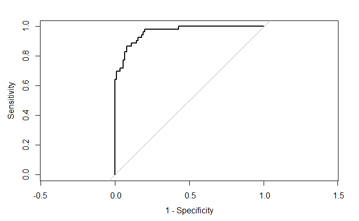

```r
fmroc <- pROC::roc(response = breast_test$diagnosis, predictor = fmpreds)
pROC::plot.roc(fmroc, response = breast_test$diagnosis, predictor = fmpreds, legacy.axes = TRUE)
```

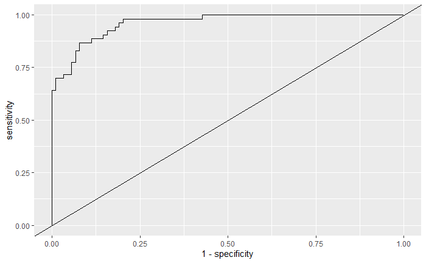

```r
pROC::ggroc(fmroc, legacy.axes = TRUE) + geom_abline(slope = 1, intercept = 0)
```

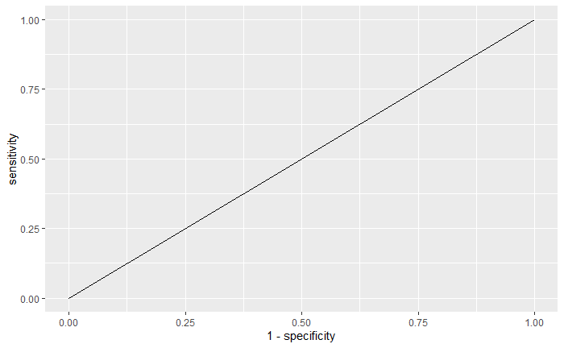

```r
random_classifier <- rep(0.5, 142)
random_roc <- pROC::roc(response = breast_test$diagnosis, predictor = random_classifier)
pROC::ggroc(random_roc, legacy.axes = TRUE)
```

### Pole pod krzywą ROC (AUC)

Krzywa ROC daje nam wizualną (i nie tylko) informację o tym, jak dobrze radzi sobie nasz klasyfikator. Konkretną charakterystyką liczbową jaką możemy obliczyć na podstawie ROC jest AUC (area under the curve), czyli pole pod krzywą. Idealny klasyfikator osiągnąłby $AUC = 1$, ponieważ punkt $(0,1)$ należałby do krzywej ROC idealnego klasyfikatora (oznaczałoby to, że mamy czułość na poziomie $1$ i $0$ błędów). Sprawdźmy AUC dla naszego klasyfikatora.

```r
fmroc$auc
```

```
Area under the curve: 0.9621
```

# Regresja logistyczna wielomianowa

Naturalnym uogólnieniem regresji logistycznej jest regresja logistyczna wielomianowa (multinomial logistic regression). Służy ona do rozwiązywania problemów klasyfikacji wielomianowej, czyli takich, w których zmienna objaśniana przyjmuje więcej niż 2 klasy. Jedną z naszych klas wybieramy na tak zwaną klasę referencyjną, będzie ona pełnić rolę klasy $0$ ze zwykłego modelu regresji logistycznej. Dla zerowej klasy zakładamy, że

$$P(Y = 0 | X = X_i) = \frac{1}{1 + \sum_{j=1}^{k-1} e^{\beta_0 X_i}},$$

a dla pozostałych

$$\hat{p_j} := P(Y = y_j | X = X_i) = \frac{e^{\beta_jX_i}}{1 + e^{\beta_jX_i}}.$$

W takim razie dostajemy, że nasz model jest ponownie liniowy po przekształceniu logitowym względem klasy referencyjnej, czyli

$$ln \frac{P(Y = y_j | X = X_i )}{P(Y = 0|X=X_i)} = \beta_jX_i.$$

Jako funkcje straty ponownie używamy log-wiarygodności (bądź entropii krzyżowej), jedyną zmianą jest to, że musimy sumować po wszystkich klasach
$$\ell(\beta | X) = \sum_{i=1}^n \sum_{j=1}^k \mbox{I}_{\{y_i = j\}} ln \hat{p}_j.$$

Uwaga: Wielomianową regresję logistyczną można też znaleźć pod nazwą regresja softmax (softmax regression). Wiąże się to z alternatywną formulacją, gdzie modelujemy
$$P(Y = y_j | X = X_i) = \frac{e^{\beta_jX_i}}{\sum_{m=1}^k e^{\beta_mX_i}}.$$
Powyższa funkcja nosi nazwę funkcji softmax. Takie sformułowanie problemu regresji prowadzi do wniosku, że jedno z prawdopodobieństw da się wyprowadzić za pomocą pozostałych i tym samym do wzorów podanych wyżej.

W *R* do budowania modelu regresji logistycznej wielomianowej służy funkcja *vglm(…, family = ‘multinomial’)* z pakietu *VGAM*.

```r
stars <- readr::read_csv('stars.csv')
stars <- stars %>% dplyr::mutate(class = ifelse(class == "QSO", 1, ifelse(class == "STAR", 2, 3))) %>%
          dplyr::mutate(class = as.factor(class))
dim(stars)
```

```
[1] 10000    18
```

```r
unique(stars$class)
```

```
[1] 2 1 3
Levels: 1 2 3
```

```r
train_test_split <- createDataPartition(stars$class, list = FALSE, p=0.75)
stars_train <- stars[train_test_split,]
stars_test <- stars[-train_test_split,]
```

```r
library(VGAM)
stars_logistic <- vglm(class ~ u + g, data = stars_train, family = 'multinomial')
summary(stars_logistic)
```

```
Call:
vglm(formula = class ~ u + g, family = "multinomial", data = stars_train)

Coefficients:
              Estimate Std. Error z value Pr(>|z|)
(Intercept):1  3.54476    0.37205   9.528  < 2e-16 ***
(Intercept):2  7.44727    0.32333  23.033  < 2e-16 ***
u:1           -1.25256    0.04023 -31.136  < 2e-16 ***
u:2           -0.09811    0.02637  -3.720 0.000199 ***
g:1            1.13329    0.04058  27.926  < 2e-16 ***
g:2           -0.27440    0.03158  -8.689  < 2e-16 ***
---
Signif. codes:  0 ‘***’ 0.001 ‘**’ 0.01 ‘*’ 0.05 ‘.’ 0.1 ‘ ’ 1

Names of linear predictors: log(mu[,1]/mu[,3]), log(mu[,2]/mu[,3])

Residual deviance: 14033.19 on 14994 degrees of freedom

Log-likelihood: -7016.595 on 14994 degrees of freedom

Number of Fisher scoring iterations: 5

Warning: Hauck-Donner effect detected in the following estimate(s):
'u:1'


Reference group is level  3  of the response
```

```r
probs_logistic <- predict(stars_logistic, stars_test, type = 'response')
head(probs_logistic)
```

```
          1          2         3
1 0.2740033 0.39356947 0.3324272
2 0.2054837 0.36448091 0.4300354
3 0.3685901 0.08994435 0.5414656
4 0.2774378 0.32139587 0.4011664
5 0.1972292 0.67414227 0.1286286
6 0.3564507 0.24226566 0.4012836
```

```r
predictions_logistic <- as.factor(apply(probs_logistic, 1, which.max))
head(predictions_logistic)
```

```
1 2 3 4 5 6
2 3 3 3 2 3
Levels: 1 2 3
```

```r
caret::confusionMatrix(data = predictions_logistic, reference = as.factor(stars_test$class))
```

```
Confusion Matrix and Statistics

          Reference
Prediction   1   2   3
         1 583  93 194
         2  13 320 280
         3 154 337 526

Overall Statistics

               Accuracy : 0.5716
                 95% CI : (0.5519, 0.5911)
    No Information Rate : 0.4
    P-Value [Acc > NIR] : < 2.2e-16

                  Kappa : 0.3502

 Mcnemar's Test P-Value : 3.79e-15

Statistics by Class:

                     Class: 1 Class: 2 Class: 3
Sensitivity            0.7773   0.4267   0.5260
Specificity            0.8360   0.8326   0.6727
Pos Pred Value         0.6701   0.5220   0.5172
Neg Pred Value         0.8975   0.7721   0.6804
Prevalence             0.3000   0.3000   0.4000
Detection Rate         0.2332   0.1280   0.2104
Detection Prevalence   0.3480   0.2452   0.4068
Balanced Accuracy      0.8067   0.6296   0.5993
```

# Klasyfikator bayesowski

Klasyfikator bayesowski jest teoretycznym klasyfikatorem, który minimalizuje ilość błędnych klasyfikacji (czyli maksymalizuje dokładność, patrz *ESL* rozdział 2.4). Jest to bardzo prosty klasyfikator, którego reguła decyzyjna ma postać

$$max_{y_i \in K} \, P(Y = y_i | X = X_i).$$

W takim razie wybieramy dla $i$-tej obserwacji tą klasę, która maksymalizuje prawdopodobieństwo warunkowe. To podejście jednak ma bardzo duży mankament. W praktyce nie zdarza się sytuacja, w której znamy rozkład warunkowy $P(Y|X)$. Klasyfikator Bayesa jest zatem teoretycznym narzędziem, które służy do wyprowadzania innych klasyfikatorów, które będą go przybliżać. Zauważmy, że jednym z nich jest regresja logistyczna, gdzie zakładamy konkretną postać $P(Y = 1 | X = X_i) = \frac{1}{1 + e^{-\beta_0 - \beta X_i}}$.

# Liniowa analiza dyskryminacyjna (LDA) Fischera

Zauważmy, że prawdopodobieństwo warunkowe z klasyfikatora Bayesa możemy zapisać jako

$$P(Y = y_i | X = X_i) = \frac{P(Y = y_i)P(X = X_i| Y = y_i)}{\sum_{j=1}^k P(Y = y_j)P(X = X_i | Y = y_j)}.$$

Każdą z wartości $P(Y = y_j)$ możemy oszacować ze zbioru treningowego jako $\frac{n_j}{n}$, gdzie $n_k$ to liczność $j$-tej klasy. Oznaczmy zatem $\pi_j = \frac{n_j}{n}$. Prawdopodobieństwo $P(X = X_i | Y = y_j)$ możemy natomiast zastąpić wiarygodnością i otrzymamy, że $P(X = X_i | Y = y_i) = f_{i}(X_i)$, gdzie $f_{i}$ to gęstość rozkładu $i$-tej klasy. Ostatecznie otrzymujemy, że
$$L(Y = y_i | X = X_i) = \frac{\pi_i f_i(X_i)}{\sum_{j=1}^k \pi_j f_j(X_i)}.$$

Kożystając z tej postaci możemy otrzymać klasyfikator, który maksymalizuje wiarygodność $L$, dla konkretnej postaci funkcji $f_i$. Oczywiście pierwszym pomysłem jaki nasuwa się jest założenie, że
$$f_i(x) = \frac{1}{(2 \pi)^{p/2} det(\Sigma_i)^{\frac{1}{2}}} exp(-\frac{1}{2} (x - \mu_i)^T \Sigma^{-1} (x - \mu_i)).$$
Innymi słowy, zakładamy, że w każdej klasie wektor losowy $X$ ma wielowymiarowy rozkład normalny o średniej $\mu_k$ i macierzy kowariancji $\Sigma_i$. Taki model nazywa się kwadratową analizą dyskryminacyjną (QDA). W specjalnym przypadku, gdy dla dowolnego $k$ mamy $\Sigma_i = \Sigma$, gdzie $\Sigma$ jest pewną macierzą (oczywiście symetryczną, dodatnio określoną etc.) otrzymujemy liniową analizę dyskryminacyjną (LDA).

Słowo “liniowy” w LDA wywodzi się z faktu, że obszary decyzyjne rozdzielane są hiperpłaszczyznami, natomiast w wypadku QDA obszary decyzyjne rozdzielane są paraboloidami. Faktycznie, spójżmy na iloraz wiarygodności dla dwóch różnych klas w wypadku LDA (zlogarytmowany, z oczywistych względów)

$$ln \frac{P(Y = y_i | X = x)}{P(Y = y_j| X = x)} = ln \frac{\pi_i}{\pi_j} - \frac{1}{2}(\mu_i + \mu_j)\Sigma^{-1}(\mu_i - \mu_j) + x^T \Sigma^{-1} (\mu_i - \mu_j).$$

Granicę decyzyjną wybieramy tam, gdzie $P(Y = y_i| X = X_i) = P(Y = y_j)$, czyli gdzie powyższe wyrażenie się zeruje, a takie wyrażenie jest liniowe względem obserwacji $x$, zatem granice decyzyjne są hiperpłaszczyznami. Równoważnie możemy zdefiniować
$$\delta_i(x) = x^T \Sigma^{-1}\mu_i - \frac{1}{2} \mu_i^T \Sigma^{-1} \mu_i + ln \pi_i$$
i podjąć decyzję za pomocą reguły $argmax_{i \in \{ 1, \dots, k\}} \delta_i(x)$.

W wypadku QDA powyższe wyrażenie się komplikuje, ze względu na brak założenia o takiej samej macierzy kowariancji dla każdej klasy. Można wyprowadzić funkcje dyskryminacjyne dla QDA, które przyjmują postać
$$\delta_i(x) = - \frac{1}{2}ln (\mbox{det}\Sigma_k) - \frac{1}{2}(x - \mu_i)^T\Sigma_k^{-1}(x - \mu_i) + ln \pi_i.$$

W *R* do przeprowadzenia LDA i QDA używamy funkcji *LDA()* i *QDA()* z biblioteki *MASS*.

```r
library(MASS)
```

```r
star_lda <- lda(class ~ u + g, data = stars_train)
star_pred <- predict(star_lda, stars_test)
caret::confusionMatrix(as.factor(stars_test$class), as.factor(star_pred$class))
```

```
Confusion Matrix and Statistics

          Reference
Prediction   1   2   3
         1 579  27 144
         2  97 326 327
         3 218 276 506

Overall Statistics

               Accuracy : 0.5644
                 95% CI : (0.5447, 0.584)
    No Information Rate : 0.3908
    P-Value [Acc > NIR] : < 2.2e-16

                  Kappa : 0.3409

 Mcnemar's Test P-Value : 9.82e-13

Statistics by Class:

                     Class: 1 Class: 2 Class: 3
Sensitivity            0.6477   0.5183   0.5179
Specificity            0.8935   0.7734   0.6756
Pos Pred Value         0.7720   0.4347   0.5060
Neg Pred Value         0.8200   0.8269   0.6860
Prevalence             0.3576   0.2516   0.3908
Detection Rate         0.2316   0.1304   0.2024
Detection Prevalence   0.3000   0.3000   0.4000
Balanced Accuracy      0.7706   0.6458   0.5968
```

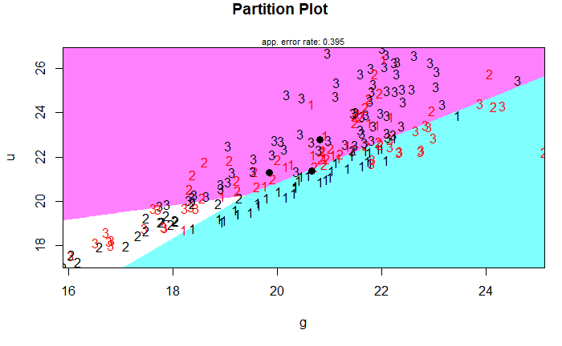

```r
library(klaR)
klaR::partimat(as.factor(class) ~ u + g, data = dplyr::sample_n(stars_train, 200), method = 'lda', prec = 500)
```

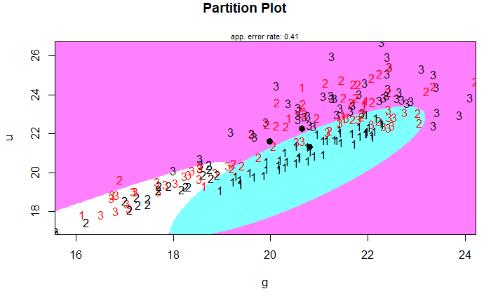

```r
klaR::partimat(as.factor(class) ~ u + g, data = dplyr::sample_n(stars_train, 200), method = 'qda', prec = 500)
```

# Cwiczenie

Stwórz najlepszy model do klasyfikacji rodzaju ciał niebieskich ze zbioru danych *stars* (przy użyciu LDA, QDA i regresji logistycznej).